# Homework - DS2

Oscar Leal - Zsofi Vamos - CEU 2020

2/17/2020

## Supervised learning with penalized models and PCA

The goal will be to predict the logarithm of the property value: logTotalValue.

```r
# more info about the data here: https://www1.nyc.gov/site/planning/data-maps/open-data/dwn-pluto-mappluto.page
data <- readRDS(url('http://www.jaredlander.com/data/manhattan_Train.rds')) %>%
  as.data.table()
#data[, logBuiltFAR := log(BuiltFAR)]
#data[, logLotFront := log(LotFront)]
#data[, logNumFloors := log(NumFloors)]

data <- data[LotArea < 25000 & BldgArea < 25000 & NumFloors < 75 & BuiltFAR < 75]
data[, logTotalValue := log(TotalValue)]

data <- data[, ZoneDist2 := NULL]
data <- data[, ZoneDist3 := NULL]
data <- data[, ZoneDist4 := NULL]
data <- data[, LotType := NULL]

data <- data[complete.cases(data)]
```

We dropped 4 variables that didn’t have any variance, and also limited the dataset to certain limit of LotArea, BldgArea, NumFloors and BuiltFAR since there were some extreme values that wouldn’t do good in our models.

1- Do a short exploration of data and find possible predictors of the target variable.

```r
skimr::skim(data)
```

```
## Skim summary statistics
##  n obs: 25089
##  n variables: 43
##
## -- Variable type:factor ---------------------------------------------------------------------------------------------------------------------------------------
##          variable missing complete     n n_unique
##      BasementType       0    25089 25089        6
##             Built       0    25089 25089       10
##             Class       0    25089 25089       25
##         Extension       0    25089 25089        4
##       FireService       0    25089 25089        3
##  HistoricDistrict       0    25089 25089        2
##      IrregularLot       0    25089 25089        2
##          Landmark       0    25089 25089        2
##           LandUse       0    25089 25089       11
##         OwnerType       0    25089 25089        5
##         Proximity       0    25089 25089        4
##    SchoolDistrict       0    25089 25089        7
##         ZoneDist1       0    25089 25089        5
##                                   top_counts ordered
##  Ful: 12454, Unk: 6089, Ful: 5373, No : 1103   FALSE
##   18t: 19795, Pre: 2025, Unk: 1351, Pos: 646   FALSE
##  Wal: 12140, Mix: 2107, Ret: 1707, Sin: 1702   FALSE
##      Unk: 19061, Ext: 5921, Gar: 58, Ext: 49   FALSE
##      Eng: 13072, Lad: 11640, Squ: 377, NA: 0   FALSE
##                  No: 17960, Yes: 7129, NA: 0   FALSE
##                  No: 20895, Yes: 4194, NA: 0   FALSE
##                   No: 24762, Yes: 327, NA: 0   FALSE
##   Mul: 9084, Mix: 6926, One: 3172, Com: 1789   FALSE
##    Unk: 15016, Pri: 8540, Mix: 801, Cit: 619   FALSE
##   Att: 16764, Not: 4154, Sem: 3625, Det: 546   FALSE
##      02: 12598, 03: 3624, 05: 2841, 06: 2262   FALSE
##    Res: 17952, Com: 5983, Man: 1028, Par: 99   FALSE
##
## -- Variable type:integer --------------------------------------------------------------------------------------------------------------------------------------
##    variable missing complete     n      mean         sd    p0   p25   p50
##    BldgArea       0    25089 25089  7827.38     5486.06     0  3770  6500
##     ComArea       0    25089 25089  1920.17     3825.85     0     0     0
##     Council       0    25089 25089     4.99        2.85     1     3     4
##   Easements       0    25089 25089     0.013       0.11     0     0     0
```

[output cut: 48 more lines]

```
##      NumFloors       0    25089 25089      4.04      1.66    0
##       ResidFAR       0    25089 25089      4.63      2.43    0
##     TotalValue       0    25089 25089 721044.5  952089.1  1080
##        p25       p50       p75       p100     hist
##      50        66        85     216       ▂▆▇▆▁▁▁▁
##      19        24        26     982       ▇▁▁▁▁▁▁▁
##       2.05      3.06      3.91   54.23    ▇▁▁▁▁▁▁▁
##       0         0         2      15       ▇▁▁▁▁▁▁▁
##       4         6.5       6.5    15       ▁▁▆▇▁▂▁▁
##      12.07     13.02     13.74   16.77    ▁▁▂▃▇▇▂▁
##      87.42     99.92    100.92  990.92    ▇▁▁▁▁▁▁▁
##      20        25        28.67 4938       ▇▁▁▁▁▁▁▁
##       3         4         5      27       ▃▇▁▁▁▁▁▁
##       3.44      4         6.02   10       ▁▁▇▇▃▁▁▃
##  175154    450882    927000       1.9e+07 ▇▁▁▁▁▁▁▁
```

```r
#glimpse(data)
```

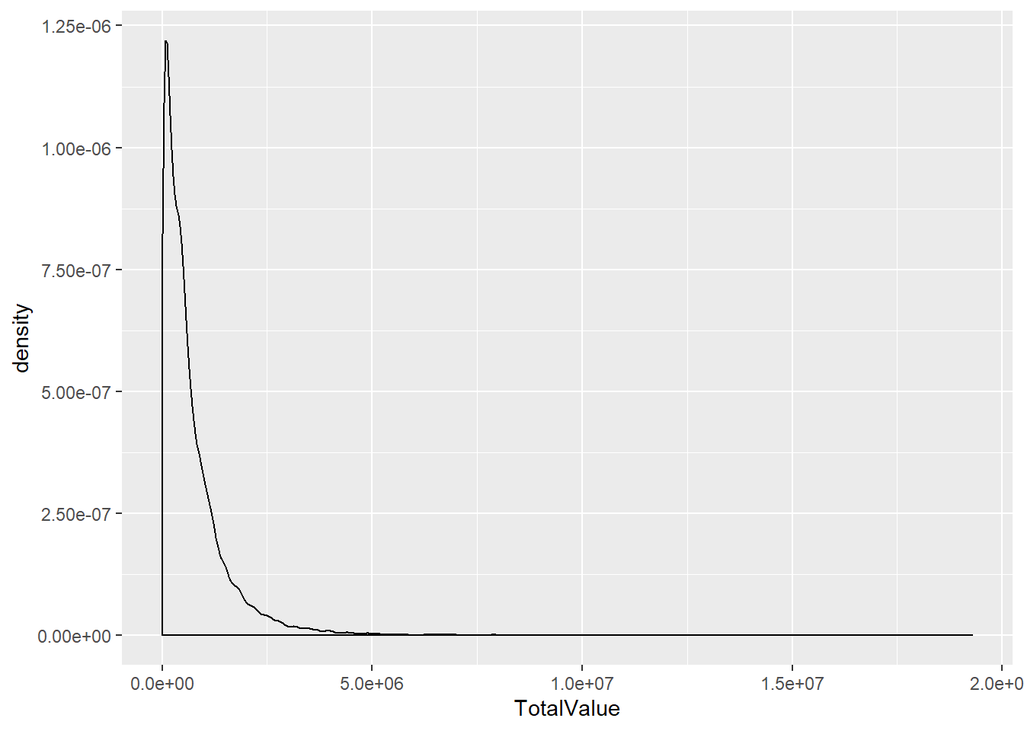

```r
ggplot(data = data, aes(x = TotalValue)) + geom_density()
```

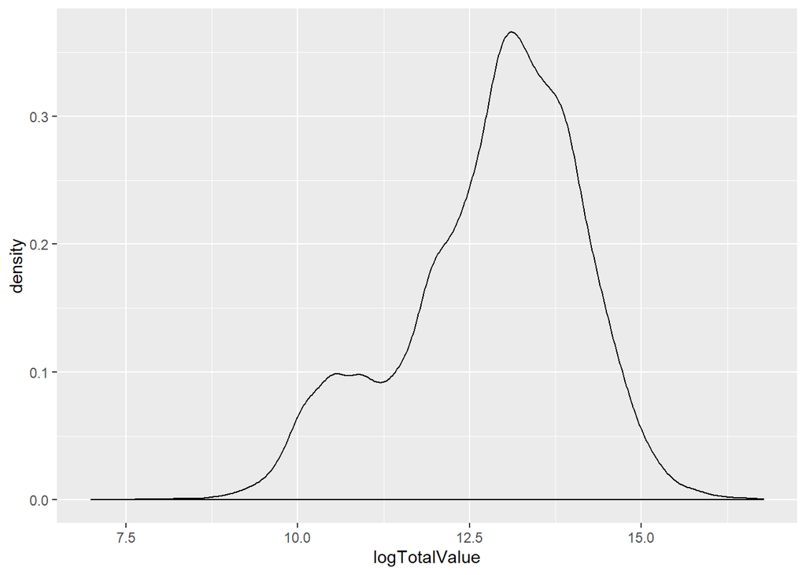

```r
ggplot(data = data, aes(x = logTotalValue)) + geom_density()
```

With the correlation matrix we select some of the variables that might be the most accurate predictors overall.

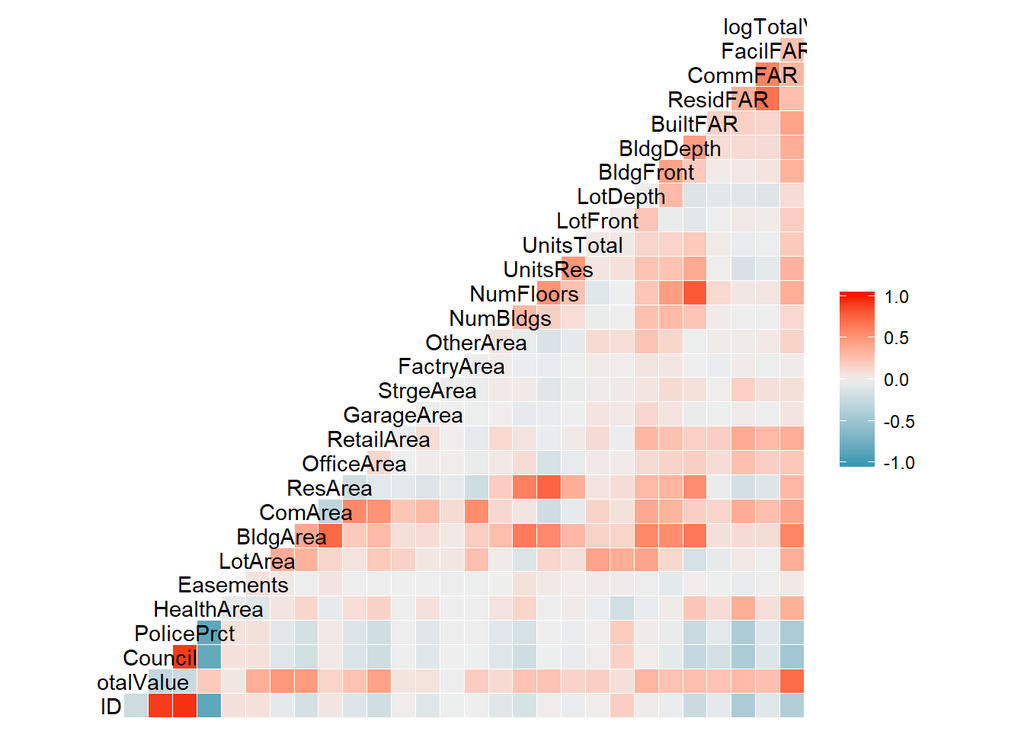

```r
ggcorr(data)
```

We select four of them to look at them better.

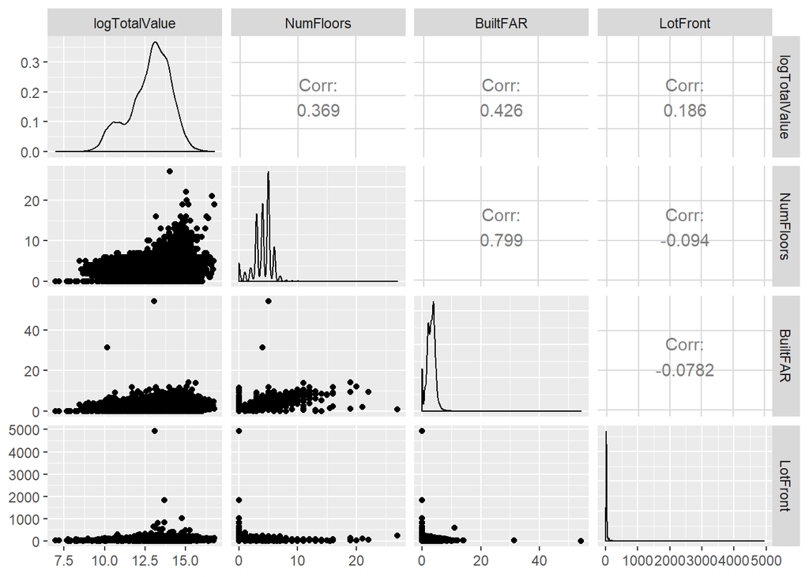

```r
#colnames(data)
ggpairs(data, columns = c("logTotalValue", "NumFloors", "BuiltFAR", "LotFront"))
```

```r
lm(logTotalValue ~ NumFloors + BuiltFAR, data = data) %>%
  tidy() %>%
  kable(digits = 3) %>%
  kable_styling(full_width = F)
```

| term | estimate | std.error | statistic | p.value |
| --- | --- | --- | --- | --- |
| (Intercept) | 11.608 | 0.019 | 597.411 | 0 |
| NumFloors | 0.063 | 0.007 | 8.478 | 0 |
| BuiltFAR | 0.321 | 0.008 | 38.126 | 0 |

```r
lm(logTotalValue ~ UnitsTotal, data = data) %>%
  tidy() %>%
  kable(digits = 3) %>%
  kable_styling(full_width = F)
```

| term | estimate | std.error | statistic | p.value |
| --- | --- | --- | --- | --- |
| (Intercept) | 12.694 | 0.009 | 1435.081 | 0 |
| UnitsTotal | 0.014 | 0.000 | 33.331 | 0 |

```r
lm(logTotalValue ~ NumFloors, data = data) %>%
  tidy() %>%
  kable(digits = 3) %>%
  kable_styling(full_width = F)
```

| term | estimate | std.error | statistic | p.value |
| --- | --- | --- | --- | --- |
| (Intercept) | 11.662 | 0.020 | 585.059 | 0 |
| NumFloors | 0.287 | 0.005 | 62.940 | 0 |

```r
lm(logTotalValue ~ BuiltFAR, data = data) %>%
  tidy() %>%
  kable(digits = 3) %>%
  kable_styling(full_width = F)
```

| term | estimate | std.error | statistic | p.value |
| --- | --- | --- | --- | --- |
| (Intercept) | 11.690 | 0.017 | 692.354 | 0 |
| BuiltFAR | 0.378 | 0.005 | 74.544 | 0 |

2- Create a training and a test set, assigning 30% of observations to the training set.

```r
set.seed(1234)
training_ratio <- 0.3
train_indices <- createDataPartition(
  y = data[["logTotalValue"]],
  times = 1,
  p = training_ratio,
  list = FALSE
)
data_train <- data[train_indices, ]
data_test <- data[-train_indices, ]

fit_control <- trainControl(method = "cv", number = 10)
fit_control_nose <- trainControl(method = "cv", number = 10, selectionFunction = "oneSE")
```

3- Use a linear regression to predict logTotalValue and use 10-fold cross validation to assess the predictive power.

```r
set.seed(857)

linear_fit <- train(
  logTotalValue ~ . -TotalValue,
  data = data_train,
  method = "lm",
  preProcess = c("center", "scale", "nzv"),
  trControl = fit_control
)

linear_fit_nose <- train(
  logTotalValue ~ . -TotalValue,
  data = data_train,
  method = "lm",
  preProcess = c("center", "scale", "nzv"),
  trControl = fit_control_nose
)

#linear_fit
RMSE(predict(linear_fit, newdata = data_test), data_test[["logTotalValue"]])
```

```
## [1] 0.6467073
```

4- Use penalized linear models for the same task. Make sure to try LASSO, Ridge and Elastic Net models. Does the best model improve on the simple linear model?

```r
features <- setdiff(names(data), c("TotalValue", "logTotalValue"))
```

```r
# glmnet needs inputs as a matrix. model.matrix: handles factor variables
# -1: we do not need the intercept as glment will automatically include it
x_train <- model.matrix( ~ . -1, data_train[, features, with = FALSE])
dim(x_train)
```

```
## [1] 7528  102
```

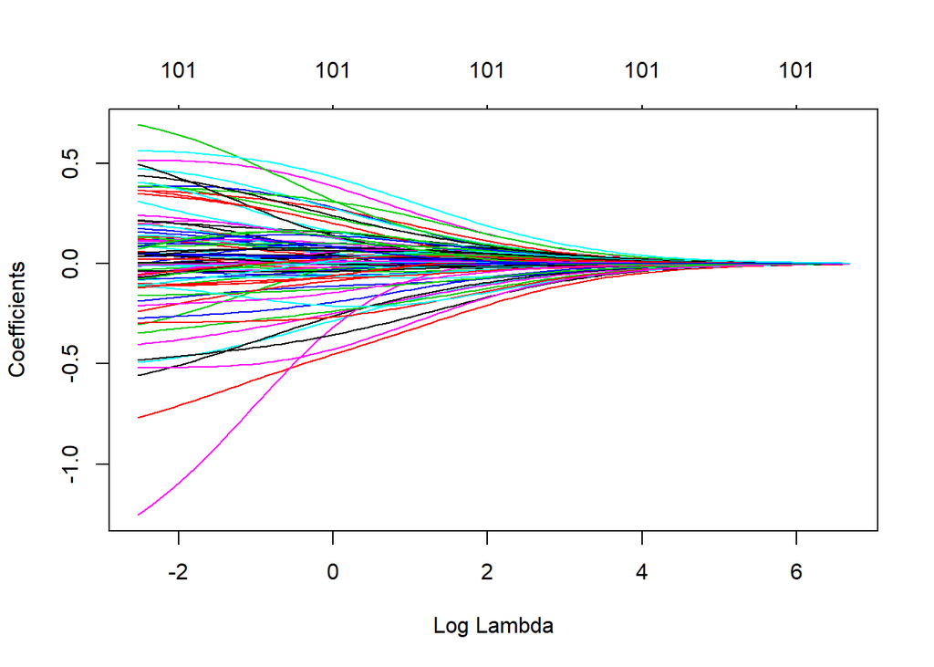

```r
# standardization of variables is automatically done by glmnet

# how much penalty do we want to apply? select with CV
lambda_grid <- 10^seq(2,-5,length=100)

set.seed(1234)
ridge_model <- glmnet(
  x = x_train, y = data_train[["logTotalValue"]],
  family = "gaussian", # for continuous response
  alpha = 0  # the ridge model
)

plot(ridge_model, xvar = "lambda")
```

Look at some individual coefficients.

```r
# helper function to extract the coefficient sequence as a data.table
get_glmnet_coeff_sequence <- function(glmnet_model) {
  coeff_sequence <- coef(glmnet_model) %>% tidy() %>% as.data.table()
  setnames(coeff_sequence, c("variable", "lambda_id", "value"))

  lambdas <- data.table(
    lambda = glmnet_model$lambda,
    lambda_id = paste0("s", 0:(length(glmnet_model$lambda) - 1))
  )

  merge(coeff_sequence, lambdas, by = "lambda_id")
}
```

```r
ridge_coeffs <- get_glmnet_coeff_sequence(ridge_model)
```

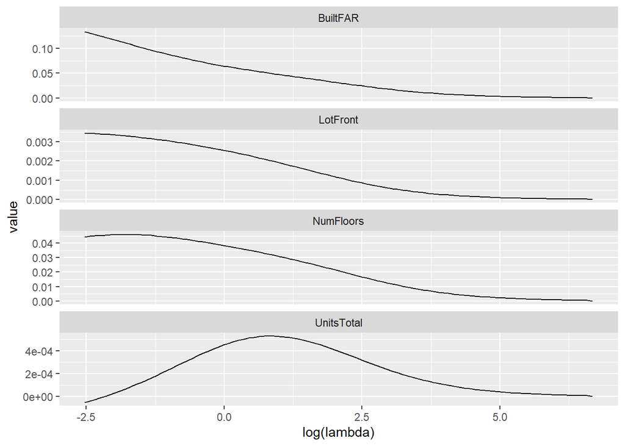

```r
selected_variables <- c("NumFloors", "BuiltFAR", "UnitsTotal",  "LotFront")
ggplot(
  data = ridge_coeffs[variable %in% selected_variables],
  aes(x = log(lambda), y = value)) +
    geom_line() +
  facet_wrap(~ variable, scales = "free_y", ncol = 1)
```

We can use cross-validation to determine the optimal penalty term weight. Two lambda values marked on the plot: one with the minimal CV RMSE, the other is the simplest model (highest lambda) which contains the optimal lambda’s error within one standard deviation. That is, it gives the simplest model that is still “good enough”.

```r
set.seed(1234)
ridge_model_cv <- cv.glmnet(
  x = x_train, y = data_train[["logTotalValue"]],
  family = "gaussian",
  alpha = 0,
  nfolds = 10
)

best_lambda <- ridge_model_cv$lambda.min
message(paste0("The optimally chosen penalty parameter: ", best_lambda))
```

```
## The optimally chosen penalty parameter: 0.0798260449174803
```

```r
highest_good_enough_lambda <- ridge_model_cv$lambda.1se
message(paste0("The highest good enough penalty parameter: ", highest_good_enough_lambda))
```

```
## The highest good enough penalty parameter: 0.896705145113834
```

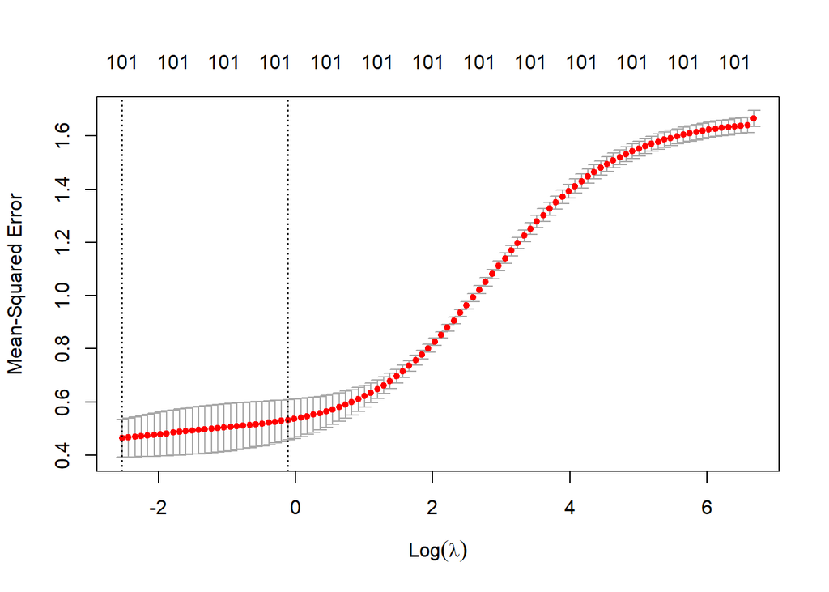

```r
plot(ridge_model_cv)
```

```r
# ridge model
ridge_tune_grid <- expand.grid(
  "alpha" = c(0),
  "lambda" = seq(0.05, 0.5, by = 0.025)
)

set.seed(857)
ridge_fit <- train(
  logTotalValue ~ . -TotalValue,
  data = data_train,
  method = "glmnet",
  preProcess = c("center", "scale", "nzv"),
  tuneGrid = ridge_tune_grid,
  trControl = fit_control
)


ridge_fit_nose <- train(
  logTotalValue ~ . -TotalValue,
  data = data_train,
  method = "glmnet",
  preProcess = c("center", "scale", "nzv"),
  tuneGrid = ridge_tune_grid,
  trControl = fit_control_nose
)
```

```r
#ridge_fit
```

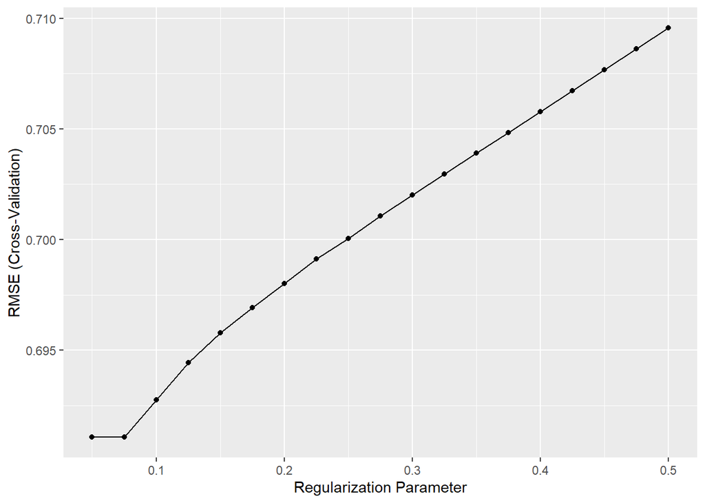

```r
ggplot(ridge_fit)
```

## Another variant: LASSO regression

While Ridge applies a constraint on the sum of squares of coefficients, LASSO does the same for the sum of the **absolute values** of coefficients.

This seemingly small difference has important sconsequences: some coefficients are set exactly to zero, others are only shrunk towards zero.

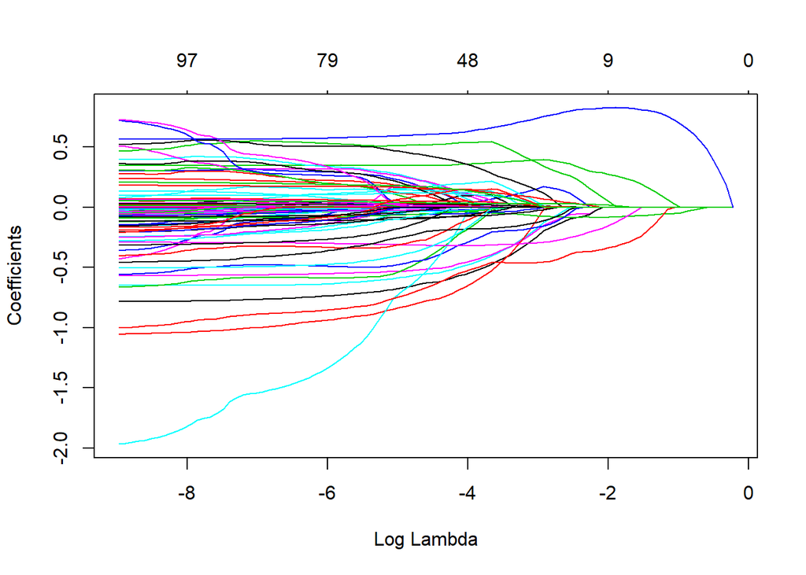

```r
set.seed(1234)
lasso_model <- glmnet(
  x = x_train, y = data_train[["logTotalValue"]],
  family = "gaussian",
  alpha = 1  # the lasso model
)

plot(lasso_model, xvar = "lambda")
```

```r
lasso_coeffs <- get_glmnet_coeff_sequence(lasso_model)
```

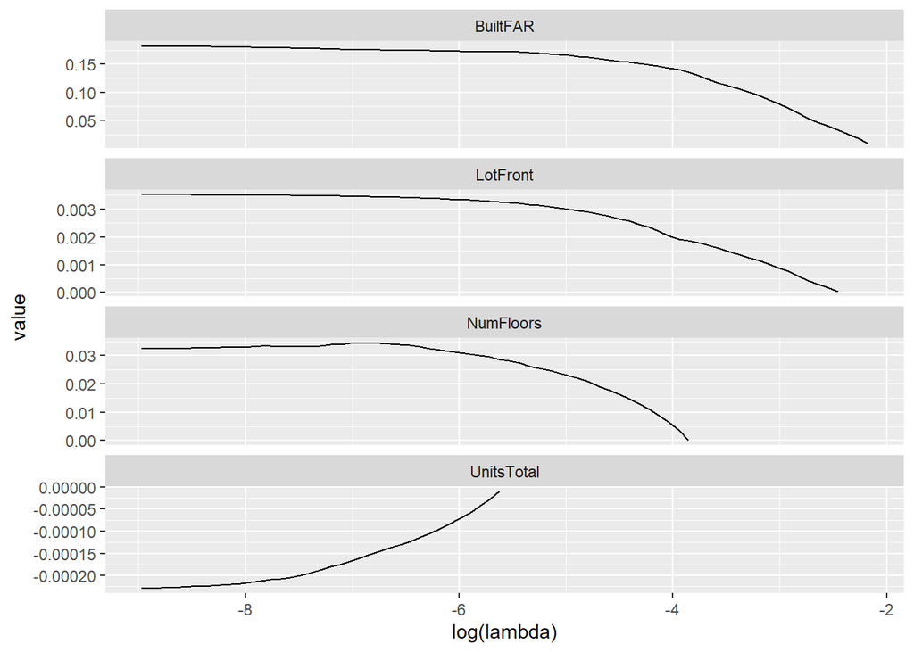

```r
ggplot(
  data = lasso_coeffs[variable %in% selected_variables],
  aes(x = log(lambda), y = value)) +
    geom_line() +
  facet_wrap(~ variable, scales = "free_y", ncol = 1)
```

Again, we can apply cross-validation to determine the optimal value for the penalty term.

```r
set.seed(1234)
lasso_model_cv <- cv.glmnet(
  x = x_train, y = data_train[["logTotalValue"]],
  family = "gaussian",
  alpha = 1,
  nfolds = 10
)

best_lambda <- lasso_model_cv$lambda.min
message(paste0("The optimally chosen penalty parameter: ", best_lambda))
```

```
## The optimally chosen penalty parameter: 0.0015670177067048
```

```r
highest_good_enough_lambda <- lasso_model_cv$lambda.1se
message(paste0("The highest good enough penalty parameter: ", highest_good_enough_lambda))
```

```
## The highest good enough penalty parameter: 0.0100729043773224
```

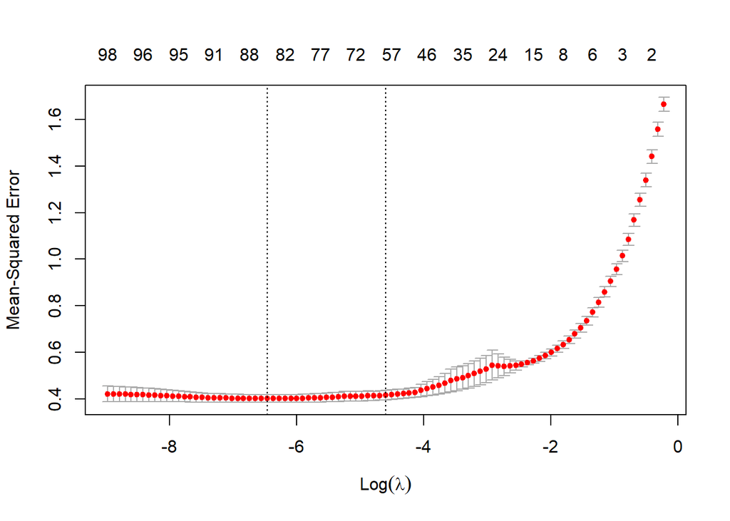

```r
plot(lasso_model_cv)
```

Fitting LASSO models with `caret` is similar to that of Ridge.

```r
tenpowers <- 10^seq(-1, -5, by = -1)

lasso_tune_grid <- expand.grid(
  "alpha" = c(1),
  "lambda" = c(tenpowers, tenpowers / 2)
)

set.seed(857)
lasso_fit <- train(
  logTotalValue ~ . -TotalValue,
  data = data_train,
  method = "glmnet",
  preProcess = c("center", "scale", "nzv"),
  tuneGrid = lasso_tune_grid,
  trControl = fit_control
)


lasso_fit_nose <- train(
  logTotalValue ~ . -TotalValue,
  data = data_train,
  method = "glmnet",
  preProcess = c("center", "scale", "nzv"),
  tuneGrid = lasso_tune_grid,
  trControl = fit_control_nose
)
```

It seems the RMSE changes much with different regularization parameters for LASSO

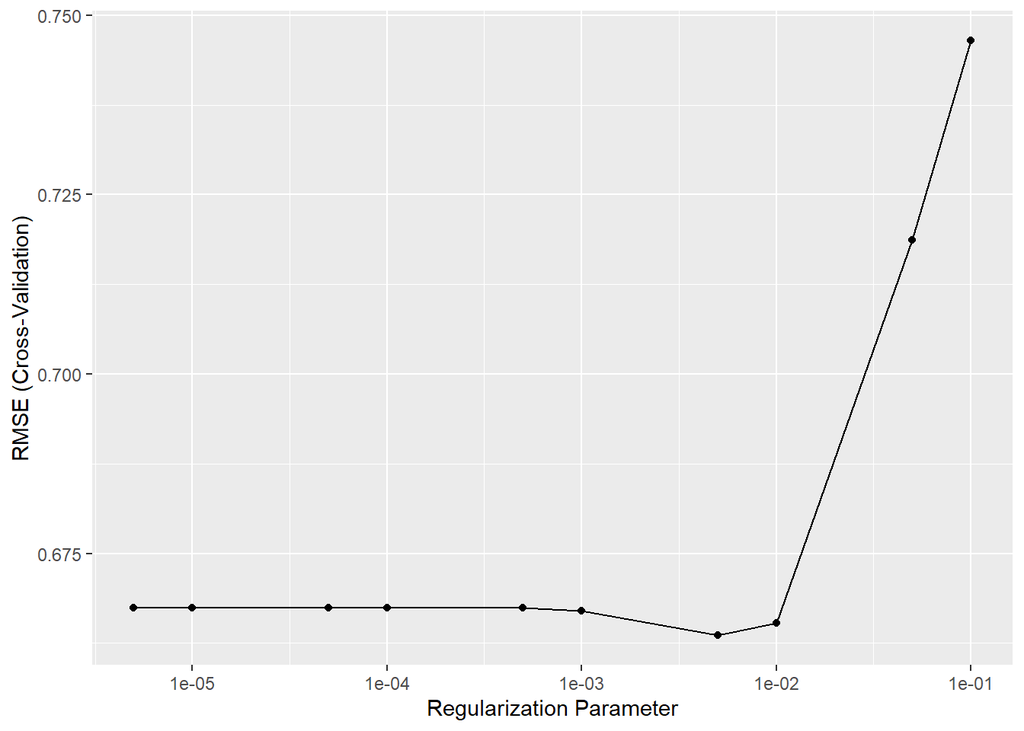

```r
ggplot(lasso_fit) + scale_x_log10()
```

## Combine Ridge and LASSO: Elastic net

We can combine both types of penalties. LASSO is attractive since it performs principled variable selection. However, when having correlated features, typically only one of them - quite arbitrarily - is kept in the model. Ridge simultaneously shrinks coefficients of these towards zero. If we apply penalties of both the absolute values and the squares of the coefficients, both virtues are retained. This method is called Elastic net.

```r
enet_tune_grid <- expand.grid(
  "alpha" = seq(0, 1, by = 0.1),
  "lambda" = union(lasso_tune_grid[["lambda"]], ridge_tune_grid[["lambda"]])
)

set.seed(857)
enet_fit <- train(
  logTotalValue ~ . -TotalValue,
  data = data_train,
  method = "glmnet",
  preProcess = c("center", "scale", "nzv"),
  tuneGrid = enet_tune_grid,
  trControl = fit_control
)

enet_fit_nose <- train(
  logTotalValue ~ . -TotalValue,
  data = data_train,
  method = "glmnet",
  preProcess = c("center", "scale", "nzv"),
  tuneGrid = enet_tune_grid,
  trControl = fit_control_nose
)
```

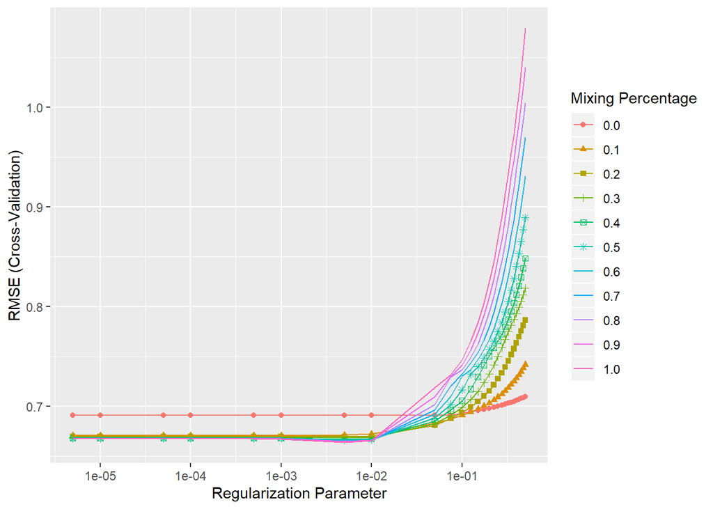

```r
ggplot(enet_fit) + scale_x_log10()
```

5- Which of the models you’ve trained is the “simples one that is still good enough”? (Hint: explore adding selectionFunction = “oneSE” to the trainControl in caret’s train. What is its effect?).

6- Now try to improve the linear model by using PCA for dimensionality reduction. Center and scale your variables and use pcr to conduct a search for the optimal number of principal components. Does PCA improve the fit over the simple linear model? (Hint: there are many factor variables. Make sure to include large number of principal components such as 60 - 90 to your search as well.)

```r
pre_process <- preProcess(data, method = c("center", "scale", "pca"))
pre_process
```

```
## Created from 25089 samples and 43 variables
##
## Pre-processing:
##   - centered (29)
##   - ignored (14)
##   - principal component signal extraction (29)
##   - scaled (29)
##
## PCA needed 19 components to capture 95 percent of the variance
```

```r
set.seed(857)
lm_fit_pca <- train(logTotalValue ~ . -TotalValue,
                    data = data,
                    method = "lm",
                    trControl = trainControl(
                      method = "cv",
                      number = 10,
                      preProcOptions = list(pcaComp = 19)), # here we selected 19 principal components
                    preProcess = c("center", "scale", "pca", "nzv")
)

#lm_fit_pca

RMSE(predict(lm_fit_pca, newdata = data_test), data_test[["logTotalValue"]])
```

```
## [1] 0.7028002
```

7- If you apply PCA prior to estimating penalized models via preProcess, does it help to achieve a better fit? (Hint: also include “nzv” to preProcess to drop zero variance features). What is your intuition why this can be the case?

```r
set.seed(857)
ridge_fit_pca <- train(
  logTotalValue ~ . -TotalValue,
  data = data_train,
  method = "glmnet",
  preProcess = c("center", "scale", "pca", "nzv"),
  tuneGrid = ridge_tune_grid,
  trControl = fit_control
)

set.seed(857)
lasso_fit_pca <- train(
  logTotalValue ~ . -TotalValue,
  data = data_train,
  method = "glmnet",
  preProcess = c("center", "scale", "pca", "nzv"),
  tuneGrid = lasso_tune_grid,
  trControl = fit_control
)

set.seed(857)
enet_fit_pca <- train(
  logTotalValue ~ . -TotalValue,
  data = data_train,
  method = "glmnet",
  preProcess = c("center", "scale", "pca", "nzv"),
  tuneGrid = enet_tune_grid,
  trControl = fit_control
)


#lm_fit_pca_nzv

RMSE(predict(ridge_fit_pca, newdata = data_test), data_test[["logTotalValue"]])
```

```
## [1] 0.6597066
```

```r
RMSE(predict(lasso_fit_pca, newdata = data_test), data_test[["logTotalValue"]])
```

```
## [1] 0.6578493
```

```r
RMSE(predict(enet_fit_pca, newdata = data_test), data_test[["logTotalValue"]])
```

```
## [1] 0.6597066
```

It doesn’t really help to use PCA in the models as all models tended to perform worse with it. Our intuitions bases itself that since we’re losing some % of the data’s variance

8- Select the best model of those you’ve trained. Evaluate your preferred model on the test set.

```r
resample_profile <- resamples(
  list("linear" = linear_fit,
       "ridge" = ridge_fit,
       "lasso" = lasso_fit,
       "elastic net" = enet_fit,
       "lm_fit_pca" = lm_fit_pca,
       "linear_nose" = linear_fit_nose,
       "lasso_nose" = lasso_fit_nose,
       "elastic net_nose" = enet_fit_nose,
       "lasso_fit_pca" = lasso_fit_pca,
       "ridge_fit_pca" = ridge_fit_pca,
       "enet_fit_pca" = enet_fit_pca
  )
)

summary(resample_profile)
```

```
##
## Call:
## summary.resamples(object = resample_profile)
##
## Models: linear, ridge, lasso, elastic net, lm_fit_pca, linear_nose, lasso_nose, elastic net_nose, lasso_fit_pca, ridge_fit_pca, enet_fit_pca
## Number of resamples: 10
##
## MAE
##                       Min.   1st Qu.    Median      Mean   3rd Qu.
## linear           0.4787712 0.4908641 0.4949398 0.4954082 0.5006400
## ridge            0.4826760 0.4955114 0.4985445 0.4987707 0.5016865
## lasso            0.4811899 0.4954856 0.4978506 0.4976837 0.5020570
## elastic net      0.4811899 0.4954856 0.4978506 0.4976837 0.5020570
## lm_fit_pca       0.5370916 0.5442495 0.5473000 0.5473786 0.5516810
## linear_nose      0.4748445 0.4880574 0.4951935 0.4946311 0.5014180
## lasso_nose       0.4785906 0.4900816 0.5023942 0.4992766 0.5033732
## elastic net_nose 0.4812056 0.4906785 0.5018063 0.5003872 0.5036893
## lasso_fit_pca    0.4908954 0.5030980 0.5056750 0.5056018 0.5075199
## ridge_fit_pca    0.4923226 0.5007705 0.5062210 0.5065725 0.5087350
## enet_fit_pca     0.4923226 0.5007705 0.5062210 0.5065725 0.5087350
##                       Max. NA's
## linear           0.5112699    0
## ridge            0.5163547    0
## lasso            0.5143612    0
## elastic net      0.5143612    0
## lm_fit_pca       0.5565688    0
## linear_nose      0.5116621    0
## lasso_nose       0.5190588    0
## elastic net_nose 0.5333343    0
## lasso_fit_pca    0.5194930    0
## ridge_fit_pca    0.5266432    0
## enet_fit_pca     0.5266432    0
##
## RMSE
##                       Min.   1st Qu.    Median      Mean   3rd Qu.
## linear           0.6249641 0.6371157 0.6425212 0.6672233 0.6480194
## ridge            0.6281420 0.6370433 0.6461341 0.6910605 0.6512826
## lasso            0.6281708 0.6383743 0.6438292 0.6635697 0.6501696
## elastic net      0.6281708 0.6383743 0.6438292 0.6635697 0.6501696
## lm_fit_pca       0.6850389 0.6969204 0.7068785 0.7260254 0.7172073
```

[output cut: 29 more lines]

```
## lasso_fit_pca    0.4583986 0.7352779 0.7452085 0.7163665 0.7511404
## ridge_fit_pca    0.4574009 0.7350648 0.7456628 0.7165926 0.7512526
## enet_fit_pca     0.4574009 0.7350648 0.7456628 0.7165926 0.7512526
##                       Max. NA's
## linear           0.7627254    0
## ridge            0.7618358    0
## lasso            0.7624448    0
## elastic net      0.7624448    0
## lm_fit_pca       0.7170318    0
## linear_nose      0.7695847    0
## lasso_nose       0.7691453    0
## elastic net_nose 0.7741098    0
## lasso_fit_pca    0.7565837    0
## ridge_fit_pca    0.7567198    0
## enet_fit_pca     0.7567198    0
```

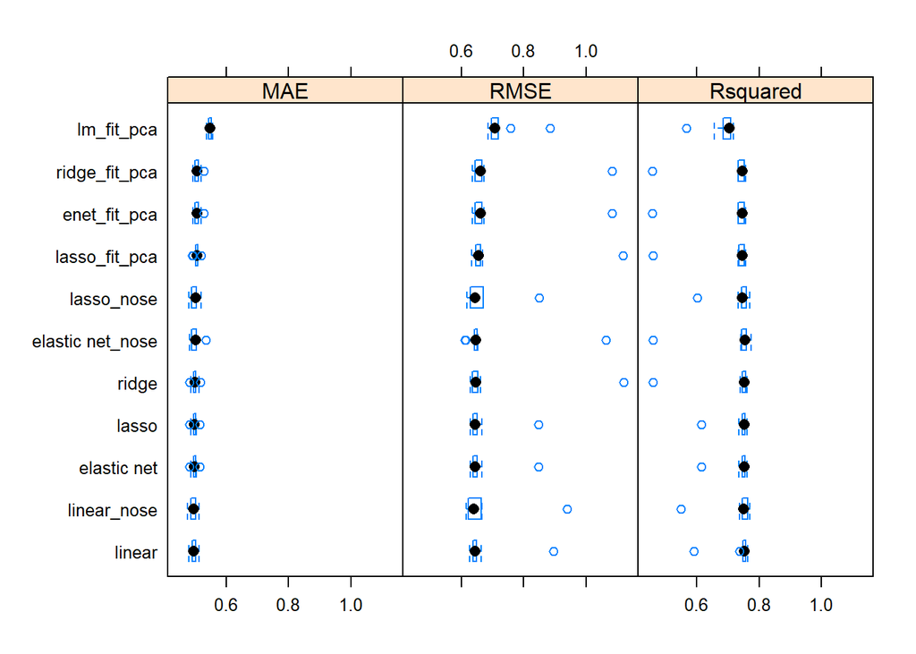

```r
bwplot(resample_profile)
```

Based in the summary, we can choose Lasso Fit with oneSE to predict in the test set.

```r
head(data_test %>% mutate(prediction = predict(lasso_fit_nose, newdata = data_test), data_test[["logTotalValue"]]) %>% select(prediction, logTotalValue), 10)
```

```
##    prediction logTotalValue
## 1    13.71831      12.69955
## 2    13.28481      13.70715
## 3    13.44402      13.72602
## 4    13.63015      13.74068
## 5    12.99778      13.19019
## 6    13.81821      13.50742
## 7    13.99003      13.75512
## 8    13.93349      13.90201
## 9    13.88900      13.47885
## 10   13.66649      13.73533
```

```r
RMSE(predict(lasso_fit_nose, newdata = data_test), data_test[["logTotalValue"]])
```

```
## [1] 0.6480047
```